# STATS 506 HW3

Author

Yixuan Jia

## Problem 1:

#### a.

```stata
. use "C:\Users\11716\Downloads\VIX_D.dta"

. merge 1:1 SEQN using "C:\Users\11716\Downloads\DEMO_D.dta"

    Result                      Number of obs
    -----------------------------------------
    Not matched                         3,368
        from master                         0  (_merge==1)
        from using                      3,368  (_merge==2)

    Matched                             6,980  (_merge==3)
    -----------------------------------------

. keep if _merge == 3
(3,368 observations deleted)

. drop _merge

. save "C:\Users\11716\Downloads\MergedData.dta", replace
(file C:\Users\11716\Downloads\MergedData.dta not found)
file C:\Users\11716\Downloads\MergedData.dta saved

.
end of do-file
```

According to the output, there are 6,980 matched data entries.

```stata
. count
  6,980

.
end of do-file
```

We can see that now the sample size is 6,980.

#### b.

```stata
. use "C:\Users\11716\Downloads\MergedData.dta"

. egen age_group = cut(RIDAGEYR), at(0(10)150)

. egen total_wears = total(VIQ220 == 1), by(age_group)

.
. gen temp1 = (VIQ220 == 1)

. gen temp2 = (VIQ220 == 2)

. egen total1 = total(temp1), by(age_group)

. egen total2 = total(temp2), by(age_group)

. gen total_count = total1 + total2

. drop temp1 temp2 total1 total2

.
. gen proportion = total_wears / total_count

.
. tabstat proportion, by(age_group) stats(mean N) save

Summary for variables: proportion
Group variable: age_group

age_group |      Mean         N
----------+--------------------
       10 |  .3208812      2207
       20 |  .3265742      1021
       30 |  .3586667       818
       40 |  .3699871       815
       50 |  .5500821       631
       60 |  .6222222       661
       70 |  .6689038       469
       80 |  .6688103       358
----------+--------------------
    Total |   .422362      6980
-------------------------------

.
end of do-file
```

From the column “Mean” of the above table, we can see the proportions for each age_group.

#### c.

```stata
. use "C:\Users\11716\Downloads\MergedData.dta", clear

.
. keep if VIQ220 != .
(433 observations deleted)

. keep if VIQ220 != 9
(2 observations deleted)

. keep if INDFMPIR != .
(298 observations deleted)

.
. gen glasses = (VIQ220 == 1)

.
. * Fit the three logistic regression models
. logit glasses RIDAGEYR

Iteration 0:  Log likelihood = -4259.5533
Iteration 1:  Log likelihood = -4058.1765
Iteration 2:  Log likelihood = -4057.9357
Iteration 3:  Log likelihood = -4057.9357

Logistic regression                                     Number of obs =  6,247
                                                        LR chi2(1)    = 403.24
                                                        Prob > chi2   = 0.0000
Log likelihood = -4057.9357                             Pseudo R2     = 0.0473

------------------------------------------------------------------------------
     glasses | Coefficient  Std. err.      z    P>|z|     [95% conf. interval]
-------------+----------------------------------------------------------------
    RIDAGEYR |   .0242228   .0012397    19.54   0.000      .021793    .0266526
       _cons |  -1.228775    .054638   -22.49   0.000    -1.335864   -1.121687
------------------------------------------------------------------------------

. local pseudoR2_1 = 1 - (e(ll)/e(ll_0))

. estimates store m1

.
. logit glasses RIDAGEYR RIDRETH1 RIAGENDR

Iteration 0:  Log likelihood = -4259.5533
Iteration 1:  Log likelihood = -4001.7382
Iteration 2:  Log likelihood = -4000.7854
Iteration 3:  Log likelihood = -4000.7853

Logistic regression                                     Number of obs =  6,247
                                                        LR chi2(3)    = 517.54
                                                        Prob > chi2   = 0.0000
Log likelihood = -4000.7853                             Pseudo R2     = 0.0608

------------------------------------------------------------------------------
     glasses | Coefficient  Std. err.      z    P>|z|     [95% conf. interval]
-------------+----------------------------------------------------------------
    RIDAGEYR |   .0246047   .0012579    19.56   0.000     .0221394    .0270701
    RIDRETH1 |   .1194197   .0231207     5.17   0.000     .0741039    .1647355
    RIAGENDR |    .499347   .0537323     9.29   0.000     .3940336    .6046604
       _cons |  -2.345872   .1221107   -19.21   0.000    -2.585204   -2.106539
------------------------------------------------------------------------------

. local pseudoR2_2 = 1 - (e(ll)/e(ll_0))

. estimates store m2

.
. logit glasses RIDAGEYR RIDRETH1 RIAGENDR INDFMPIR

Iteration 0:  Log likelihood = -4259.5533
Iteration 1:  Log likelihood = -3966.8788
Iteration 2:  Log likelihood = -3965.3949
Iteration 3:  Log likelihood = -3965.3948

Logistic regression                                     Number of obs =  6,247
                                                        LR chi2(4)    = 588.32
                                                        Prob > chi2   = 0.0000
Log likelihood = -3965.3948                             Pseudo R2     = 0.0691

------------------------------------------------------------------------------
     glasses | Coefficient  Std. err.      z    P>|z|     [95% conf. interval]
-------------+----------------------------------------------------------------
    RIDAGEYR |   .0237627    .001262    18.83   0.000     .0212892    .0262362
    RIDRETH1 |   .0927756   .0235641     3.94   0.000     .0465909    .1389603
    RIAGENDR |   .5185953   .0541213     9.58   0.000     .4125196     .624671
    INDFMPIR |   .1426011   .0170108     8.38   0.000     .1092606    .1759416
       _cons |  -2.634169   .1284572   -20.51   0.000    -2.885941   -2.382398
------------------------------------------------------------------------------

. local pseudoR2_3 = 1 - (e(ll)/e(ll_0))

. estimates store m3

.
. * Create the table with the desired metrics
. esttab m1 m2 m3, eform cells("b p") stats(N aic) ///
>     addnote("Pseudo R2: `pseudoR2_1' `pseudoR2_2' `pseudoR2_3'")

------------------------------------------------------------------------------------------
                      (1)                       (2)                       (3)
                  glasses                   glasses                   glasses
                        b            p            b            p            b            p
------------------------------------------------------------------------------------------
glasses
RIDAGEYR         1.024519            0      1.02491            0     1.024047            0
RIDRETH1                                   1.126843     2.40e-07     1.097216     .0000824
RIAGENDR                                   1.647645            0     1.679667            0
INDFMPIR                                                              1.15327            0
------------------------------------------------------------------------------------------
N                    6247                      6247                      6247
aic              8119.871                  8009.571                   7940.79
------------------------------------------------------------------------------------------
Exponentiated coefficients
Pseudo R2:  .0473330299421751       .0607500328167399     .0690585378250731
.
end of do-file
```

#### d.

```stata
 * The difference between odds of men and women being wears of glasess/contact lenses for distance is
>  actually exp(coefficient for Gender)
. di "Difference between Odds Ratio for gender: " exp(_b[RIAGENDR])
Difference between Odds Ratio for gender: 1.6796666

.
. tabulate RIAGENDR glasses, chi2

           |        glasses
  RIAGENDR |         0          1 |     Total
-----------+----------------------+----------
         1 |     1,919      1,134 |     3,053
         2 |     1,673      1,521 |     3,194
-----------+----------------------+----------
     Total |     3,592      2,655 |     6,247

          Pearson chi2(1) =  70.1108   Pr = 0.000

.
end of do-file
```

The difference between odds of men and women being wears of glasess/contact lenses for distance is actually exp(coefficient for Gender), which is 1.6796666 as shown in the outputs.

To test whether the *proportion* of wearers of glasses/contact lenses for distance vision differs between men and women, I used the chi-squared test, we can see the frequency of each gender wearing or not wearing glasses/contact. The p-value of the test is 0.000 < 0.05, therefore we can conclude that the proportion of wearers of glasses/contact lenses for distance vision indeed differs significantly between men and women.

## Problem 2:

Some set-ups:

```r
library(DBI)
library(RSQLite)
sakila <- dbConnect(RSQLite::SQLite(), "sakila_master.db")
dbListTables(sakila)
```

```
 [1] "actor"                  "address"                "category"
 [4] "city"                   "country"                "customer"
 [7] "customer_list"          "film"                   "film_actor"
[10] "film_category"          "film_list"              "film_text"
[13] "inventory"              "language"               "payment"
[16] "rental"                 "sales_by_film_category" "sales_by_store"
[19] "staff"                  "staff_list"             "store"
```

```r
gg <- function(x) {
  dbGetQuery(sakila, x)
}
```

#### a.

```r
gg("
   SELECT l.name, COUNT(*)
   FROM language AS l
   JOIN film AS f
   ON l.language_id = f.language_id
   GROUP BY l.name
   ")
```

```
     name COUNT(*)
1 English     1000
```

According to the query, there are no film with other languages aside from English in this data set.

#### b.

Method 1:

```r
library(dplyr)
data_b <- gg("
   SELECT f.film_id, c.name
   FROM film AS f
   LEFT JOIN film_category AS fc
   ON f.film_id = fc.film_id
   LEFT JOIN category c
   ON fc.category_id = c.category_id
   ")

result <- data_b %>%
  group_by(name) %>%
  summarise(movie_count = n()) %>%
  arrange(desc(movie_count)) %>%
  head(1)

result
```

```
# A tibble: 1 × 2
  name   movie_count
  <chr>        <int>
1 Sports          74
```

Method 2:

```r
gg("
   SELECT c.name, COUNT(f.film_id) AS movie_count
   FROM film AS f
   LEFT JOIN film_category AS fc
   ON f.film_id = fc.film_id
   LEFT JOIN category c
   ON fc.category_id = c.category_id
   GROUP BY c.name
   ORDER BY movie_count DESC
   LIMIT 1
   ")
```

```
    name movie_count
1 Sports          74
```

According to results from both methods, the genre “Sports” is the most common, 74 movies are of the “Sports” genre.

#### c.

Method 1:

```r
data_c <- gg("
   SELECT c.customer_id, co.country
   FROM customer AS c
   LEFT JOIN address AS a
   ON c.address_id = a.address_id
   LEFT JOIN city AS ci
   ON a.city_id = ci.city_id
   LEFT JOIN country AS co
   ON ci.country_id = co.country_id
   ")

result <- data_c %>%
  group_by(country) %>%
  summarise(customer_count = n()) %>%
  filter(customer_count == 9)

result
```

```
# A tibble: 1 × 2
  country        customer_count
  <chr>                   <int>
1 United Kingdom              9
```

Method 2:

```r
gg("
   SELECT co.country, COUNT(c.customer_id) AS customer_count
   FROM customer AS c
   LEFT JOIN address AS a
   ON c.address_id = a.address_id
   LEFT JOIN city AS ci
   ON a.city_id = ci.city_id
   LEFT JOIN country AS co
   ON ci.country_id = co.country_id
   GROUP BY co.country
   HAVING customer_count = 9
   ")
```

```
         country customer_count
1 United Kingdom              9
```

According to the results from both methods, the country “United Kingdom” has exactly 9 customers.

## Problem 3:

```r
library(scales)
df <- read.csv("us-500.csv")
#df
```

#### a.

```r
# Create a function to extract the TLD from an email address
extract_tld <- function(email) {
  parts <- strsplit(email, "@")
  tld <- strsplit(parts[[1]][2], "\\.")
  return(tld[[1]][2])
}

# Apply the function to the "email" column and count the occurrences
df$TLD <- sapply(df$email, extract_tld)

tld_counts <- table(df$TLD)

p1 <- tld_counts["net"] / sum(tld_counts)

print(percent(p1, accuracy = 0.01))
```

```
     net
"14.00%"
```

#### b.

```r
# Create a function to check if there is any nonalphanumeric except for the "@" and "."

has_non_alphanumeric <- function(email) {
  parts <- strsplit(email, "@")
  domain_parts <- strsplit(parts[[1]][2], ".") # check if there are any non-alphanumeric in the domain part

  if (grepl("[^A-Za-z0-9]", parts[[1]][1])) {
    return(TRUE)
  }
  else if (grepl("[^A-Za-z0-9]", domain_parts[[1]][1])) {
    return(TRUE)
  }

  else {
    return(FALSE)
  }
}

df$has_non_alphanumeric <- sapply(df$email, has_non_alphanumeric)

p2 <- sum(df$has_non_alphanumeric)/nrow(df)

print(percent(p2, accuracy = 0.01))
```

```
[1] "50.60%"
```

#### c.

```r
# Combine "phone1" and "phone2"
all_phone_numbers <- c(df$phone1, df$phone2)

# Initialize an empty vector
area_codes = vector("numeric", length = 1000)

# Extract area code
for (i in 1:length(all_phone_numbers)){
  area_codes[i] <- strsplit(all_phone_numbers[i], "-")[[1]][1]
}

area_code_counts <- table(area_codes)
area_code_counts[which.max(area_code_counts)]
```

```
973
 36
```

The most common area code is “973” amongst all phone numbers (phone1 + phone2).

#### d.

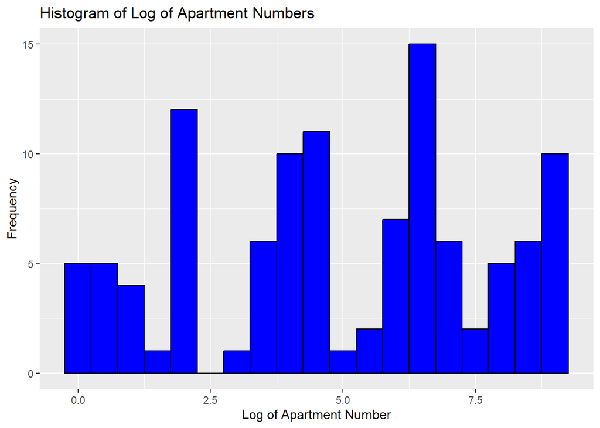

```r
library(ggplot2)

addresses <- df$address
street_and_unit <- matrix(0, nrow = length(addresses), ncol = 2)

# Extract the apartment number
for (i in 1:length(addresses)) {
  parts <- strsplit(addresses[i], "#")
  street_and_unit[i, 1] <- addresses[i]
  street_and_unit[i, 2] <- parts[[1]][2]
}

colnames(street_and_unit) <- c("Address", "ApartmentNumber")

#set it as a data frame
street_and_unit <- data.frame(street_and_unit)

street_and_unit <- street_and_unit[!is.na(street_and_unit$ApartmentNumber), ]

street_and_unit$ApartmentNumber <- as.numeric(street_and_unit$ApartmentNumber)

# Calculate the log of apartment numbers
street_and_unit$log_ApartmentNumber <- log(street_and_unit$ApartmentNumber)

ggplot(street_and_unit, aes(x=log_ApartmentNumber)) +
  geom_histogram(binwidth=0.5, fill="blue", color="black") +
  labs(title="Histogram of Log of Apartment Numbers", x="Log of Apartment Number", y="Frequency")
```

#### e.

```r
# Create a function to extract the leading digit of the apartment number
extract_leading_digit <- function(address) {
  parts <- strsplit(address, "#")
  unit_number <- parts[[1]][2]
  return(substr(unit_number, 1, 1))
}

# Initialize a vector to store leading digits
Leading_digit <- vector("numeric", length = length(addresses))
for (i in 1:length(addresses)) {
  Leading_digit[i] <- extract_leading_digit(addresses[i])
}

apartment_number_leading <- data.frame(Leading_digit = Leading_digit)

# Converting leading_digit to a numeric variable
apartment_number_leading$Leading_digit <- as.numeric(apartment_number_leading$Leading_digit)

# Calculate the theoretical probability of the corresponding leadind digit
apartment_number_leading$Theoretical_prob <- log10(1+1/apartment_number_leading$Leading_digit)

# Delete the entries without an apartment number
apartment_number_leading <- apartment_number_leading[!is.na(apartment_number_leading$Leading_digit), ]

#Calculate the observed frequency of this leading number
freq_table <- table(apartment_number_leading$Leading_digit)
apartment_number_leading$Observed_freq <- freq_table[as.character(apartment_number_leading$Leading_digit)]

# Delete the duplicates so that it's easier to understand and it's ready to perform chi-square test
apartment_number_leading <- apartment_number_leading[!duplicated(apartment_number_leading[, "Leading_digit"]), ]

apartment_number_leading
```

[output not shown]

```r
test_result <- chisq.test(apartment_number_leading$Observed_freq, p = apartment_number_leading$Theoretical_prob)
print(test_result)
```

```
    Chi-squared test for given probabilities

data:  apartment_number_leading$Observed_freq
X-squared = 61.86, df = 8, p-value = 2.009e-10
```

In order to compare the observed frequencies and the theoretical probabilities, I used the chi-squared test. We can see that the p-value is very small, a lot less than 0.05, so we can conclude that the actual frequencies do not follow the theoretical distribution, i.e., I think the apartment numbers would not pass as real data.

#### f.

```r
extract_last_digit <- function(address) {
  street_number <- sub("^([0-9]+).*", "\\1", address)
  return(substr(street_number, nchar(street_number), nchar(street_number)))
}

Last_digit <- vector("numeric", length = length(addresses))
for (i in 1:length(addresses)) {
  Last_digit[i] <- extract_last_digit(addresses[i])
}

street_number_last <- data.frame(Last_digit = Last_digit)

# Converting leading_digit to a numeric variable
street_number_last$Last_digit <- as.numeric(street_number_last$Last_digit)

# Calculate the theoretical probability of the corresponding leadind digit
street_number_last$Theoretical_prob <- log10(1+1/street_number_last$Last_digit)

# Delete the entries without an apartment number
street_number_last <- street_number_last[!is.na(street_number_last$Last_digit), ]

#Calculate the observed frequency of this leading number
freq_table2 <- table(street_number_last$Last_digit)
street_number_last$Observed_freq <- freq_table2[as.character(street_number_last$Last_digit)]

# Delete the duplicates so that it's easier to understand and it's ready to perform chi-square test
street_number_last <- street_number_last[!duplicated(street_number_last[, "Last_digit"]), ]

# Delete the row with digit 0, because we cannot calculate the probability according to Benford's Law
street_number_last <- street_number_last[street_number_last$Last_digit != 0,  ]

street_number_last
```

```
   Last_digit Theoretical_prob Observed_freq
1           9       0.04575749            66
2           4       0.09691001            53
3           8       0.05115252            45
6           3       0.12493874            51
7           7       0.05799195            56
9           5       0.07918125            52
11          1       0.30103000            41
15          6       0.06694679            43
18          2       0.17609126            54
```

```r
test_result <- chisq.test(street_number_last$Observed_freq, p = street_number_last$Theoretical_prob)

print(test_result)
```

```
    Chi-squared test for given probabilities

data:  street_number_last$Observed_freq
X-squared = 238.73, df = 8, p-value < 2.2e-16
```